# Ford GoBike Data Exploration

## Contents

- Introduction
- Preliminary Wrangling
- Data Exploration
- Conclusion
- References

## Introduction

This document explores a dataset containing FordGo journey information from the year 2018.

## Preliminary Wrangling

Although this project focusses on communication of data findings, wrangling had to be first be performed to ensure the dataset was tidy for analysis and findings were accurate.

### Gathering Data

```python
# import all packages and set plots to be embedded inline
import numpy as np
import pandas as pd
import matplotlib.pyplot as plt
import seaborn as sb
import os
import glob
import requests
import io
import zipfile

%matplotlib inline
```

The relevant files were retrieved programmatically and then concatenated and stored in a pandas DataFrame as below.

```python
# Getting the data, extracting zip files and storing in folder
for month in range(1, 13):
    month_string = str(month)
    month_leading_zero = month_string.zfill(2)
    print(month_leading_zero)
    bike_data_url_2018 = 'https://s3.amazonaws.com/fordgobike-data/2018' + month_leading_zero + \
    '-fordgobike-tripdata.csv.zip'
    response_2018 = requests.get(bike_data_url_2018)
    ## Extract zip file;
    unzipped_files_2018 = zipfile.ZipFile(io.BytesIO(response_2018.content))
    unzipped_files_2018.extractall('2018-fordgobike-tripdata')
```

```
01
02
03
04
05
06
07
08
09
10
11
12
```

```python
# load saved dataset and store in `df`
df = pd.concat([pd.read_csv(f) for f in glob.glob('2018-fordgobike-tripdata/*.csv')])
df.info(null_counts=True)
```

```
<class 'pandas.core.frame.DataFrame'>
Int64Index: 1863721 entries, 0 to 131362
Data columns (total 16 columns):
 #   Column                   Non-Null Count    Dtype
---  ------                   --------------    -----
 0   duration_sec             1863721 non-null  int64
 1   start_time               1863721 non-null  object
 2   end_time                 1863721 non-null  object
 3   start_station_id         1851950 non-null  float64
 4   start_station_name       1851950 non-null  object
 5   start_station_latitude   1863721 non-null  float64
 6   start_station_longitude  1863721 non-null  float64
 7   end_station_id           1851950 non-null  float64
 8   end_station_name         1851950 non-null  object
 9   end_station_latitude     1863721 non-null  float64
 10  end_station_longitude    1863721 non-null  float64
 11  bike_id                  1863721 non-null  int64
 12  user_type                1863721 non-null  object
 13  member_birth_year        1753003 non-null  float64
 14  member_gender            1753354 non-null  object
 15  bike_share_for_all_trip  1863721 non-null  object
dtypes: float64(7), int64(2), object(7)
memory usage: 241.7+ MB
```

```python
# create the original concatenated df as a csv before cleaning so I can open in Excel to visually assess
df.to_csv('2018-fordgobike-data.csv', index = False)
```

### Assessing Data

```python
# resetting index
df.reset_index(drop=True, inplace = True)
```

```python
df
```

|  | duration_sec | start_time | end_time | start_station_id | start_station_name | start_station_latitude | start_station_longitude | end_station_id | end_station_name | end_station_latitude | end_station_longitude | bike_id | user_type | member_birth_year | member_gender | bike_share_for_all_trip |
| --- | --- | --- | --- | --- | --- | --- | --- | --- | --- | --- | --- | --- | --- | --- | --- | --- |
| 0 | 75284 | 2018-01-31 22:52:35.2390 | 2018-02-01 19:47:19.8240 | 120.0 | Mission Dolores Park | 37.761420 | -122.426435 | 285.0 | Webster St at O'Farrell St | 37.783521 | -122.431158 | 2765 | Subscriber | 1986.0 | Male | No |
| 1 | 85422 | 2018-01-31 16:13:34.3510 | 2018-02-01 15:57:17.3100 | 15.0 | San Francisco Ferry Building (Harry Bridges Pl... | 37.795392 | -122.394203 | 15.0 | San Francisco Ferry Building (Harry Bridges Pl... | 37.795392 | -122.394203 | 2815 | Customer | NaN | NaN | No |
| 2 | 71576 | 2018-01-31 14:23:55.8890 | 2018-02-01 10:16:52.1160 | 304.0 | Jackson St at 5th St | 37.348759 | -121.894798 | 296.0 | 5th St at Virginia St | 37.325998 | -121.877120 | 3039 | Customer | 1996.0 | Male | No |
| 3 | 61076 | 2018-01-31 14:53:23.5620 | 2018-02-01 07:51:20.5000 | 75.0 | Market St at Franklin St | 37.773793 | -122.421239 | 47.0 | 4th St at Harrison St | 37.780955 | -122.399749 | 321 | Customer | NaN | NaN | No |
| 4 | 39966 | 2018-01-31 19:52:24.6670 | 2018-02-01 06:58:31.0530 | 74.0 | Laguna St at Hayes St | 37.776435 | -122.426244 | 19.0 | Post St at Kearny St | 37.788975 | -122.403452 | 617 | Subscriber | 1991.0 | Male | No |
| ... | ... | ... | ... | ... | ... | ... | ... | ... | ... | ... | ... | ... | ... | ... | ... | ... |
| 1863716 | 473 | 2018-12-01 00:11:54.8110 | 2018-12-01 00:19:48.5470 | 345.0 | Hubbell St at 16th St | 37.766474 | -122.398295 | 81.0 | Berry St at 4th St | 37.775880 | -122.393170 | 3035 | Subscriber | 1982.0 | Female | No |
| 1863717 | 841 | 2018-12-01 00:02:48.7260 | 2018-12-01 00:16:49.7660 | 10.0 | Washington St at Kearny St | 37.795393 | -122.404770 | 58.0 | Market St at 10th St | 37.776619 | -122.417385 | 2034 | Subscriber | 1999.0 | Female | No |
| 1863718 | 260 | 2018-12-01 00:05:27.6150 | 2018-12-01 00:09:47.9560 | 245.0 | Downtown Berkeley BART | 37.870139 | -122.268422 | 255.0 | Virginia St at Shattuck Ave | 37.876573 | -122.269528 | 2243 | Subscriber | 1991.0 | Male | No |
| 1863719 | 292 | 2018-12-01 00:03:06.5490 | 2018-12-01 00:07:59.0800 | 93.0 | 4th St at Mission Bay Blvd S | 37.770407 | -122.391198 | 126.0 | Esprit Park | 37.761634 | -122.390648 | 545 | Subscriber | 1963.0 | Male | No |
| 1863720 | 150 | 2018-12-01 00:03:05.7420 | 2018-12-01 00:05:36.0260 | 107.0 | 17th St at Dolores St | 37.763015 | -122.426497 | 119.0 | 18th St at Noe St | 37.761047 | -122.432642 | 4319 | Subscriber | NaN | NaN | No |

1863721 rows × 16 columns

```python
df.sample(10)
```

|  | duration_sec | start_time | end_time | start_station_id | start_station_name | start_station_latitude | start_station_longitude | end_station_id | end_station_name | end_station_latitude | end_station_longitude | bike_id | user_type | member_birth_year | member_gender | bike_share_for_all_trip |
| --- | --- | --- | --- | --- | --- | --- | --- | --- | --- | --- | --- | --- | --- | --- | --- | --- |
| 1532480 | 577 | 2018-10-10 17:22:44.8970 | 2018-10-10 17:32:21.9910 | 24.0 | Spear St at Folsom St | 37.789677 | -122.390428 | 67.0 | San Francisco Caltrain Station 2 (Townsend St... | 37.776639 | -122.395526 | 2174 | Subscriber | 1976.0 | Male | No |
| 880947 | 904 | 2018-07-22 18:46:45.0380 | 2018-07-22 19:01:49.2930 | 120.0 | Mission Dolores Park | 37.761420 | -122.426435 | 139.0 | Garfield Square (25th St at Harrison St) | 37.751017 | -122.411901 | 1797 | Customer | 1989.0 | Male | No |
| 1364283 | 648 | 2018-09-07 06:41:04.8900 | 2018-09-07 06:51:52.8910 | 109.0 | 17th St at Valencia St | 37.763316 | -122.421904 | 34.0 | Father Alfred E Boeddeker Park | 37.783988 | -122.412408 | 4424 | Subscriber | 1960.0 | Male | No |
| 747032 | 963 | 2018-06-12 16:32:03.8920 | 2018-06-12 16:48:06.8940 | 162.0 | Franklin St at 9th St | 37.800516 | -122.272080 | 193.0 | Grand Ave at Santa Clara Ave | 37.812744 | -122.247215 | 3692 | Subscriber | 1984.0 | Male | Yes |
| 1497539 | 547 | 2018-10-16 09:52:08.1000 | 2018-10-16 10:01:15.3070 | 248.0 | Telegraph Ave at Ashby Ave | 37.855956 | -122.259795 | 258.0 | University Ave at Oxford St | 37.872355 | -122.266447 | 3100 | Subscriber | 1993.0 | Male | No |
| 687539 | 830 | 2018-06-21 14:10:04.5420 | 2018-06-21 14:23:54.7490 | 30.0 | San Francisco Caltrain (Townsend St at 4th St) | 37.776598 | -122.395282 | 343.0 | Bryant St at 2nd St | 37.783172 | -122.393572 | 3569 | Customer | 1988.0 | Male | No |
| 233958 | 1487 | 2018-03-24 10:00:44.9900 | 2018-03-24 10:25:32.5830 | 166.0 | College Ave at Alcatraz Ave | 37.851376 | -122.252523 | 7.0 | Frank H Ogawa Plaza | 37.804562 | -122.271738 | 1097 | Customer | NaN | NaN | No |
| 435580 | 417 | 2018-04-03 08:49:45.0420 | 2018-04-03 08:56:42.8810 | 219.0 | Marston Campbell Park | 37.809824 | -122.280192 | 160.0 | West Oakland BART Station | 37.805318 | -122.294837 | 200 | Subscriber | 1988.0 | Male | No |
| 565410 | 251 | 2018-05-10 17:13:32.1270 | 2018-05-10 17:17:43.7830 | 75.0 | Market St at Franklin St | 37.773793 | -122.421239 | 56.0 | Koshland Park | 37.773414 | -122.427317 | 3986 | Subscriber | 1961.0 | Female | No |
| 150400 | 311 | 2018-02-13 12:41:49.6690 | 2018-02-13 12:47:00.8800 | 202.0 | Washington St at 8th St | 37.800754 | -122.274894 | 163.0 | Lake Merritt BART Station | 37.797320 | -122.265320 | 1549 | Subscriber | 1991.0 | Female | Yes |

```python
# assess number of nulls
df.info(verbose = True, null_counts=True)
```

```
<class 'pandas.core.frame.DataFrame'>
RangeIndex: 1863721 entries, 0 to 1863720
Data columns (total 16 columns):
 #   Column                   Non-Null Count    Dtype
---  ------                   --------------    -----
 0   duration_sec             1863721 non-null  int64
 1   start_time               1863721 non-null  object
 2   end_time                 1863721 non-null  object
 3   start_station_id         1851950 non-null  float64
 4   start_station_name       1851950 non-null  object
 5   start_station_latitude   1863721 non-null  float64
 6   start_station_longitude  1863721 non-null  float64
 7   end_station_id           1851950 non-null  float64
 8   end_station_name         1851950 non-null  object
 9   end_station_latitude     1863721 non-null  float64
 10  end_station_longitude    1863721 non-null  float64
 11  bike_id                  1863721 non-null  int64
 12  user_type                1863721 non-null  object
 13  member_birth_year        1753003 non-null  float64
 14  member_gender            1753354 non-null  object
 15  bike_share_for_all_trip  1863721 non-null  object
dtypes: float64(7), int64(2), object(7)
memory usage: 227.5+ MB
```

```python
df.describe()
```

|  | duration_sec | start_station_id | start_station_latitude | start_station_longitude | end_station_id | end_station_latitude | end_station_longitude | bike_id | member_birth_year |
| --- | --- | --- | --- | --- | --- | --- | --- | --- | --- |
| count | 1.863721e+06 | 1.851950e+06 | 1.863721e+06 | 1.863721e+06 | 1.851950e+06 | 1.863721e+06 | 1.863721e+06 | 1.863721e+06 | 1.753003e+06 |
| mean | 8.573026e+02 | 1.196744e+02 | 3.776678e+01 | -1.223492e+02 | 1.181730e+02 | 3.776690e+01 | -1.223487e+02 | 2.296851e+03 | 1.983088e+03 |
| std | 2.370379e+03 | 1.003976e+02 | 1.057689e-01 | 1.654634e-01 | 1.004403e+02 | 1.056483e-01 | 1.650597e-01 | 1.287733e+03 | 1.044289e+01 |
| min | 6.100000e+01 | 3.000000e+00 | 3.726331e+01 | -1.224737e+02 | 3.000000e+00 | 3.726331e+01 | -1.224737e+02 | 1.100000e+01 | 1.881000e+03 |
| 25% | 3.500000e+02 | 3.300000e+01 | 3.777106e+01 | -1.224114e+02 | 3.000000e+01 | 3.777106e+01 | -1.224094e+02 | 1.225000e+03 | 1.978000e+03 |
| 50% | 5.560000e+02 | 8.900000e+01 | 3.778107e+01 | -1.223974e+02 | 8.800000e+01 | 3.778127e+01 | -1.223971e+02 | 2.338000e+03 | 1.985000e+03 |
| 75% | 8.720000e+02 | 1.860000e+02 | 3.779625e+01 | -1.222865e+02 | 1.830000e+02 | 3.779728e+01 | -1.222894e+02 | 3.333000e+03 | 1.991000e+03 |
| max | 8.636600e+04 | 3.810000e+02 | 4.551000e+01 | -7.357000e+01 | 3.810000e+02 | 4.551000e+01 | -7.357000e+01 | 6.234000e+03 | 2.000000e+03 |

```python
# checking for duplicates
sum(df.duplicated())
```

```
0
```

The minimum member birth year is 1881 which is clearly an error. Erroneous birth years will be examined further in the cleaning section of this report.

```python
# how many entries indicate someone over 70 is riding a bike
df.query("member_birth_year < 1938")
```

|  | duration_sec | start_time | end_time | start_station_id | start_station_name | start_station_latitude | start_station_longitude | end_station_id | end_station_name | end_station_latitude | end_station_longitude | bike_id | user_type | member_birth_year | member_gender | bike_share_for_all_trip |
| --- | --- | --- | --- | --- | --- | --- | --- | --- | --- | --- | --- | --- | --- | --- | --- | --- |
| 93 | 465 | 2018-01-31 21:56:17.6330 | 2018-01-31 22:04:02.8280 | 3.0 | Powell St BART Station (Market St at 4th St) | 37.786375 | -122.404904 | 60.0 | 8th St at Ringold St | 37.774520 | -122.409449 | 1168 | Subscriber | 1911.0 | Other | No |
| 622 | 923 | 2018-01-31 19:01:30.2850 | 2018-01-31 19:16:54.0080 | 5.0 | Powell St BART Station (Market St at 5th St) | 37.783899 | -122.408445 | 23.0 | The Embarcadero at Steuart St | 37.791464 | -122.391034 | 2186 | Subscriber | 1936.0 | Male | Yes |
| 1065 | 549 | 2018-01-31 18:01:24.7290 | 2018-01-31 18:10:34.2680 | 78.0 | Folsom St at 9th St | 37.773717 | -122.411647 | 5.0 | Powell St BART Station (Market St at 5th St) | 37.783899 | -122.408445 | 2920 | Subscriber | 1911.0 | Other | No |
| 1254 | 568 | 2018-01-31 17:40:47.7010 | 2018-01-31 17:50:16.5020 | 223.0 | 16th St Mission BART Station 2 | 37.764765 | -122.420091 | 60.0 | 8th St at Ringold St | 37.774520 | -122.409449 | 3363 | Subscriber | 1911.0 | Other | No |
| 1532 | 658 | 2018-01-31 17:11:03.4240 | 2018-01-31 17:22:01.9530 | 19.0 | Post St at Kearny St | 37.788975 | -122.403452 | 30.0 | San Francisco Caltrain (Townsend St at 4th St) | 37.776598 | -122.395282 | 2992 | Subscriber | 1902.0 | Male | No |
| ... | ... | ... | ... | ... | ... | ... | ... | ... | ... | ... | ... | ... | ... | ... | ... | ... |
| 1859247 | 497 | 2018-12-02 17:07:54.1090 | 2018-12-02 17:16:11.4640 | 240.0 | Haste St at Telegraph Ave | 37.866043 | -122.258804 | 18.0 | Telegraph Ave at Alcatraz Ave | 37.850222 | -122.260172 | 476 | Subscriber | 1900.0 | Male | Yes |
| 1859869 | 924 | 2018-12-02 14:19:17.3580 | 2018-12-02 14:34:42.1630 | 98.0 | Valencia St at 16th St | 37.765052 | -122.421866 | 21.0 | Montgomery St BART Station (Market St at 2nd St) | 37.789625 | -122.400811 | 1090 | Subscriber | 1900.0 | Male | No |
| 1862588 | 132 | 2018-12-01 14:48:34.3480 | 2018-12-01 14:50:46.4120 | 173.0 | Shattuck Ave at 55th St | 37.840364 | -122.264488 | 174.0 | Shattuck Ave at 51st St | 37.836801 | -122.264004 | 1387 | Subscriber | 1900.0 | Male | Yes |
| 1863208 | 392 | 2018-12-01 11:40:36.4540 | 2018-12-01 11:47:09.1380 | 197.0 | El Embarcadero at Grand Ave | 37.808848 | -122.249680 | 195.0 | Bay Pl at Vernon St | 37.812314 | -122.260779 | 1098 | Subscriber | 1900.0 | Female | No |
| 1863253 | 410 | 2018-12-01 11:17:31.4910 | 2018-12-01 11:24:21.8430 | 195.0 | Bay Pl at Vernon St | 37.812314 | -122.260779 | 197.0 | El Embarcadero at Grand Ave | 37.808848 | -122.249680 | 1098 | Subscriber | 1900.0 | Female | No |

2427 rows × 16 columns

#### Quality

- Missing data - there are null values in a number of different columns
- Erroneous datatypes ('start_time' and 'end_time' should be datetime data type, 'member_birth_year' should be changed to an integer datatype, 'user_type' and 'member_gender' could be changed to a category datatype, 'bike_share_for_all_trip' could also be changed to a boolean datatype, 'bike_id', 'start_station_id' and 'end_station_id' should be changed to strings)
- The minimum birth year is shown as 1881 - there are a number of member_birth_years that indicate people are over 70 years old which seems extremely unlikely that they would be riding bikes

#### Note of Possible Additions/Changes which can be made during exploration

- Duration in minutes column could be added which is easier to comprehend for communicating findings
- Can make a month column to investigate the effect of time of year
- Distance could be considered but this would be as the crow flies and not necessarily the route taken by the rider

### Cleaning Data

The first step of the cleaning process was to create a copy of the original dataset.

```python
# make a copy
df_clean = df.copy()
```

##### Missing Data - There are null values in a number of different columns

###### Define

Remove the null values from the dataset.

###### Code

```python
# dropping rows with null values
df_clean.dropna(inplace=True)
```

```python
df_clean.reset_index(drop=True, inplace = True)
```

###### Test

```python
# checking null count
df_clean.info(null_counts = True)
```

```
<class 'pandas.core.frame.DataFrame'>
RangeIndex: 1741556 entries, 0 to 1741555
Data columns (total 16 columns):
 #   Column                   Non-Null Count    Dtype
---  ------                   --------------    -----
 0   duration_sec             1741556 non-null  int64
 1   start_time               1741556 non-null  object
 2   end_time                 1741556 non-null  object
 3   start_station_id         1741556 non-null  float64
 4   start_station_name       1741556 non-null  object
 5   start_station_latitude   1741556 non-null  float64
 6   start_station_longitude  1741556 non-null  float64
 7   end_station_id           1741556 non-null  float64
 8   end_station_name         1741556 non-null  object
 9   end_station_latitude     1741556 non-null  float64
 10  end_station_longitude    1741556 non-null  float64
 11  bike_id                  1741556 non-null  int64
 12  user_type                1741556 non-null  object
 13  member_birth_year        1741556 non-null  float64
 14  member_gender            1741556 non-null  object
 15  bike_share_for_all_trip  1741556 non-null  object
dtypes: float64(7), int64(2), object(7)
memory usage: 212.6+ MB
```

##### Erroneous datatypes ('start_time' and 'end_time' should be datetime data type, 'member_birth_year' should be changed to an integer datatype, 'user_type' and 'member_gender' could be changed to a category datatype, 'bike_share_for_all_trip' could also be changed to a category datatype, 'bike_id', 'start_station_id' and 'end_station_id' should be changed to strings)

###### Define

Change the datatypes as follows:

- 'start_time' and 'end_time' to be converted to datetime data type
- 'member_birth_year' to be converted to an integer datatype
- 'bike_id', 'start_station_id' and 'end_station_id' to be converted to string, i.e. object datatype since no numerical calculations should be performed
- 'user_type' and 'member_gender' to be converted to a category datatype
- 'bike_share_for_all_trip' to be converted to a a category datatype

###### Code

```python
# convert to datetime datatype
df_clean.start_time = pd.to_datetime(df_clean.start_time)
```

```python
# convert to datetime datatype
df_clean.end_time = pd.to_datetime(df_clean.end_time)
```

```python
# convert to integer datatype
df_clean.member_birth_year = df_clean.member_birth_year.astype('int')
```

```python
# convert to string, object datatype
df_clean.bike_id = df_clean.bike_id.astype('object')
```

```python
# convert to string, object datatype
df_clean.start_station_id = df_clean.start_station_id.astype('object')
```

```python
# convert to string, object datatype
df_clean.end_station_id = df_clean.end_station_id.astype('object')
```

```python
# convert to category datatype
df_clean.user_type = df_clean.user_type.astype('category')
```

```python
# convert to category datatype
df_clean.member_gender = df_clean.member_gender.astype('category')
```

```python
# convert to category datatype
df_clean.bike_share_for_all_trip = df_clean.bike_share_for_all_trip.astype('category')
```

###### Test

```python
df_clean.info()
```

```
<class 'pandas.core.frame.DataFrame'>
RangeIndex: 1741556 entries, 0 to 1741555
Data columns (total 16 columns):
 #   Column                   Dtype
---  ------                   -----
 0   duration_sec             int64
 1   start_time               datetime64[ns]
 2   end_time                 datetime64[ns]
 3   start_station_id         object
 4   start_station_name       object
 5   start_station_latitude   float64
 6   start_station_longitude  float64
 7   end_station_id           object
 8   end_station_name         object
 9   end_station_latitude     float64
 10  end_station_longitude    float64
 11  bike_id                  object
 12  user_type                category
 13  member_birth_year        int32
 14  member_gender            category
 15  bike_share_for_all_trip  category
dtypes: category(3), datetime64[ns](2), float64(4), int32(1), int64(1), object(5)
memory usage: 171.1+ MB
```

##### The minimum birth year is shown as 1881 - there are a number of member_birth_years that indicate people are over 70 years old which seems extremely unlikely

###### Define

```python
df_clean.member_birth_year.describe()
```

```
count    1.741556e+06
mean     1.983061e+03
std      1.045133e+01
min      1.881000e+03
25%      1.978000e+03
50%      1.985000e+03
75%      1.991000e+03
max      2.000000e+03
Name: member_birth_year, dtype: float64
```

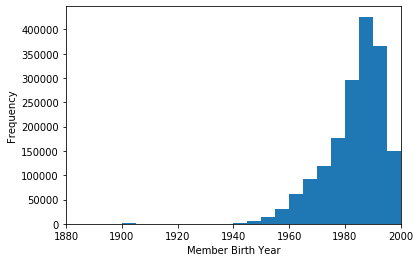

```python
bin_edges = np.arange (0, df_clean['member_birth_year'].max()+5, 5)
plt.hist(data = df_clean, x = 'member_birth_year', bins = bin_edges)
plt.xlim(1880, 2000)
plt.xlabel('Member Birth Year')
plt.ylabel('Frequency');
```

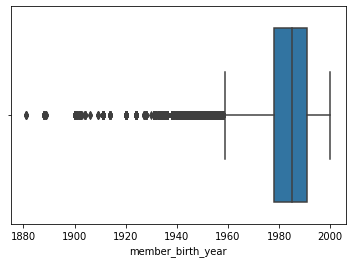

```python
# look for outliers
sb.boxplot(x=df_clean['member_birth_year'])
```

```python
# Using the Interquartile Range to understand outliers
q1 = df_clean.member_birth_year.quantile(0.25)
q3 = df_clean.member_birth_year.quantile(0.75)
iqr = q3 - q1
print(q1)
print(q3)
print(iqr)
```

```
1978.0
1991.0
13.0
```

```python
lower_whisker = q1 - 1.5 * iqr
print(lower_whisker)
```

```
1958.5
```

```python
df_clean.query("member_birth_year < 1958")
```

|  | duration_sec | start_time | end_time | start_station_id | start_station_name | start_station_latitude | start_station_longitude | end_station_id | end_station_name | end_station_latitude | end_station_longitude | bike_id | user_type | member_birth_year | member_gender | bike_share_for_all_trip |
| --- | --- | --- | --- | --- | --- | --- | --- | --- | --- | --- | --- | --- | --- | --- | --- | --- |
| 8 | 601 | 2018-01-31 23:29:46.832 | 2018-01-31 23:39:48.000 | 223 | 16th St Mission BART Station 2 | 37.764765 | -122.420091 | 86 | Market St at Dolores St | 37.769305 | -122.426826 | 3016 | Subscriber | 1957 | Male | No |
| 17 | 150 | 2018-01-31 23:10:09.586 | 2018-01-31 23:12:40.333 | 182 | 19th Street BART Station | 37.809013 | -122.268247 | 183 | Telegraph Ave at 19th St | 37.808702 | -122.269927 | 3468 | Subscriber | 1945 | Male | Yes |
| 73 | 284 | 2018-01-31 22:05:46.628 | 2018-01-31 22:10:31.084 | 60 | 8th St at Ringold St | 37.774520 | -122.409449 | 89 | Division St at Potrero Ave | 37.769218 | -122.407646 | 3624 | Subscriber | 1956 | Male | No |
| 84 | 465 | 2018-01-31 21:56:17.633 | 2018-01-31 22:04:02.828 | 3 | Powell St BART Station (Market St at 4th St) | 37.786375 | -122.404904 | 60 | 8th St at Ringold St | 37.774520 | -122.409449 | 1168 | Subscriber | 1911 | Other | No |
| 96 | 388 | 2018-01-31 21:48:13.944 | 2018-01-31 21:54:42.501 | 172 | College Ave at Taft Ave | 37.841800 | -122.251535 | 210 | 45th St at Manila | 37.833294 | -122.256224 | 1555 | Subscriber | 1951 | Male | No |
| ... | ... | ... | ... | ... | ... | ... | ... | ... | ... | ... | ... | ... | ... | ... | ... | ... |
| 1741189 | 331 | 2018-12-01 10:42:19.412 | 2018-12-01 10:47:50.734 | 26 | 1st St at Folsom St | 37.787290 | -122.394380 | 21 | Montgomery St BART Station (Market St at 2nd St) | 37.789625 | -122.400811 | 2665 | Subscriber | 1948 | Male | No |
| 1741229 | 722 | 2018-12-01 10:11:46.721 | 2018-12-01 10:23:49.142 | 296 | 5th St at Virginia St | 37.325998 | -121.877120 | 298 | Oak St at 1st St | 37.322125 | -121.881090 | 2595 | Subscriber | 1957 | Male | Yes |
| 1741341 | 613 | 2018-12-01 08:41:29.588 | 2018-12-01 08:51:42.826 | 76 | McCoppin St at Valencia St | 37.771662 | -122.422423 | 127 | Valencia St at 21st St | 37.756708 | -122.421025 | 1220 | Subscriber | 1945 | Male | Yes |
| 1741439 | 166 | 2018-12-01 05:51:47.167 | 2018-12-01 05:54:33.610 | 64 | 5th St at Brannan St | 37.776754 | -122.399018 | 67 | San Francisco Caltrain Station 2 (Townsend St... | 37.776639 | -122.395526 | 1864 | Subscriber | 1950 | Male | No |
| 1741532 | 230 | 2018-12-01 00:41:31.955 | 2018-12-01 00:45:22.416 | 312 | San Jose Diridon Station | 37.329732 | -121.901782 | 314 | Santa Clara St at Almaden Blvd | 37.333988 | -121.894902 | 1379 | Subscriber | 1957 | Male | No |

36644 rows × 16 columns

36,644 rows would be lost if we removed all of these points. Instead those with birth years in the bottom 1% will be removed and the dataset truncated.

```python
df.member_birth_year.describe(percentiles = [.01])
```

```
count    1.753003e+06
mean     1.983088e+03
std      1.044289e+01
min      1.881000e+03
1%       1.953000e+03
50%      1.985000e+03
max      2.000000e+03
Name: member_birth_year, dtype: float64
```

Those born before 1953 and therefore over the age of 65 in the year 2018 will be removed from the dataset. Those born in the year 2000 which is the max year would have been 18 so this seems reasonable that this would be the age range of bike riders.

```python
df_clean.query("member_birth_year < 1953")
```

|  | duration_sec | start_time | end_time | start_station_id | start_station_name | start_station_latitude | start_station_longitude | end_station_id | end_station_name | end_station_latitude | end_station_longitude | bike_id | user_type | member_birth_year | member_gender | bike_share_for_all_trip |
| --- | --- | --- | --- | --- | --- | --- | --- | --- | --- | --- | --- | --- | --- | --- | --- | --- |
| 17 | 150 | 2018-01-31 23:10:09.586 | 2018-01-31 23:12:40.333 | 182 | 19th Street BART Station | 37.809013 | -122.268247 | 183 | Telegraph Ave at 19th St | 37.808702 | -122.269927 | 3468 | Subscriber | 1945 | Male | Yes |
| 84 | 465 | 2018-01-31 21:56:17.633 | 2018-01-31 22:04:02.828 | 3 | Powell St BART Station (Market St at 4th St) | 37.786375 | -122.404904 | 60 | 8th St at Ringold St | 37.774520 | -122.409449 | 1168 | Subscriber | 1911 | Other | No |
| 96 | 388 | 2018-01-31 21:48:13.944 | 2018-01-31 21:54:42.501 | 172 | College Ave at Taft Ave | 37.841800 | -122.251535 | 210 | 45th St at Manila | 37.833294 | -122.256224 | 1555 | Subscriber | 1951 | Male | No |
| 185 | 789 | 2018-01-31 21:00:26.345 | 2018-01-31 21:13:35.795 | 127 | Valencia St at 21st St | 37.756708 | -122.421025 | 72 | Page St at Scott St | 37.772406 | -122.435650 | 1396 | Subscriber | 1951 | Male | No |
| 283 | 235 | 2018-01-31 20:33:25.687 | 2018-01-31 20:37:20.870 | 176 | MacArthur BART Station | 37.828410 | -122.266315 | 150 | Adeline St at 40th St | 37.831277 | -122.278267 | 502 | Subscriber | 1943 | Male | No |
| ... | ... | ... | ... | ... | ... | ... | ... | ... | ... | ... | ... | ... | ... | ... | ... | ... |
| 1741104 | 410 | 2018-12-01 11:17:31.491 | 2018-12-01 11:24:21.843 | 195 | Bay Pl at Vernon St | 37.812314 | -122.260779 | 197 | El Embarcadero at Grand Ave | 37.808848 | -122.249680 | 1098 | Subscriber | 1900 | Female | No |
| 1741118 | 1497 | 2018-12-01 10:52:40.195 | 2018-12-01 11:17:37.196 | 15 | San Francisco Ferry Building (Harry Bridges Pl... | 37.795392 | -122.394203 | 81 | Berry St at 4th St | 37.775880 | -122.393170 | 593 | Subscriber | 1947 | Male | No |
| 1741189 | 331 | 2018-12-01 10:42:19.412 | 2018-12-01 10:47:50.734 | 26 | 1st St at Folsom St | 37.787290 | -122.394380 | 21 | Montgomery St BART Station (Market St at 2nd St) | 37.789625 | -122.400811 | 2665 | Subscriber | 1948 | Male | No |
| 1741341 | 613 | 2018-12-01 08:41:29.588 | 2018-12-01 08:51:42.826 | 76 | McCoppin St at Valencia St | 37.771662 | -122.422423 | 127 | Valencia St at 21st St | 37.756708 | -122.421025 | 1220 | Subscriber | 1945 | Male | Yes |
| 1741439 | 166 | 2018-12-01 05:51:47.167 | 2018-12-01 05:54:33.610 | 64 | 5th St at Brannan St | 37.776754 | -122.399018 | 67 | San Francisco Caltrain Station 2 (Townsend St... | 37.776639 | -122.395526 | 1864 | Subscriber | 1950 | Male | No |

16418 rows × 16 columns

###### Code

```python
df_clean.drop(df_clean[df_clean.member_birth_year < 1953].index, inplace=True)
```

```python
df_clean.reset_index(drop=True, inplace = True)
```

###### Test

```python
df_clean.query("member_birth_year < 1953")
```

|  | duration_sec | start_time | end_time | start_station_id | start_station_name | start_station_latitude | start_station_longitude | end_station_id | end_station_name | end_station_latitude | end_station_longitude | bike_id | user_type | member_birth_year | member_gender | bike_share_for_all_trip |
| --- | --- | --- | --- | --- | --- | --- | --- | --- | --- | --- | --- | --- | --- | --- | --- | --- |

```python
df_clean.info(null_counts=True)
```

```
<class 'pandas.core.frame.DataFrame'>
RangeIndex: 1725138 entries, 0 to 1725137
Data columns (total 16 columns):
 #   Column                   Non-Null Count    Dtype
---  ------                   --------------    -----
 0   duration_sec             1725138 non-null  int64
 1   start_time               1725138 non-null  datetime64[ns]
 2   end_time                 1725138 non-null  datetime64[ns]
 3   start_station_id         1725138 non-null  object
 4   start_station_name       1725138 non-null  object
 5   start_station_latitude   1725138 non-null  float64
 6   start_station_longitude  1725138 non-null  float64
 7   end_station_id           1725138 non-null  object
 8   end_station_name         1725138 non-null  object
 9   end_station_latitude     1725138 non-null  float64
 10  end_station_longitude    1725138 non-null  float64
 11  bike_id                  1725138 non-null  object
 12  user_type                1725138 non-null  category
 13  member_birth_year        1725138 non-null  int32
 14  member_gender            1725138 non-null  category
 15  bike_share_for_all_trip  1725138 non-null  category
dtypes: category(3), datetime64[ns](2), float64(4), int32(1), int64(1), object(5)
memory usage: 169.5+ MB
```

```python
df_clean.describe()
```

|  | duration_sec | start_station_latitude | start_station_longitude | end_station_latitude | end_station_longitude | member_birth_year |
| --- | --- | --- | --- | --- | --- | --- |
| count | 1.725138e+06 | 1.725138e+06 | 1.725138e+06 | 1.725138e+06 | 1.725138e+06 | 1.725138e+06 |
| mean | 7.731038e+02 | 3.776858e+01 | -1.223511e+02 | 3.776868e+01 | -1.223506e+02 | 1.983431e+03 |
| std | 1.945196e+03 | 1.018145e-01 | 1.195945e-01 | 1.016607e-01 | 1.189998e-01 | 9.706350e+00 |
| min | 6.100000e+01 | 3.726331e+01 | -1.224737e+02 | 3.726331e+01 | -1.224737e+02 | 1.953000e+03 |
| 25% | 3.450000e+02 | 3.777106e+01 | -1.224116e+02 | 3.777106e+01 | -1.224094e+02 | 1.978000e+03 |
| 50% | 5.430000e+02 | 3.778107e+01 | -1.223974e+02 | 3.778127e+01 | -1.223971e+02 | 1.986000e+03 |
| 75% | 8.390000e+02 | 3.779728e+01 | -1.222880e+02 | 3.779728e+01 | -1.222894e+02 | 1.991000e+03 |
| max | 8.628100e+04 | 3.788022e+01 | -1.218333e+02 | 3.788022e+01 | -1.218333e+02 | 2.000000e+03 |

## Data Exploration

#### Main Features of the Dataset

It is of interest to find out which features are best for predicting the duration and also the features affecting frequency of bike trips.

#### Features to Support Investigation

It is expected that time of day and day of the week will have the strongest effect on both the frequency and duration of the bike ride, with longer and more frequent bike rides during the commuting hours. Additionally it is expected that time of year as well as user type, that is whether the rider is a subscriber or customer, and member birth year may affect the frequency and duration of trips. Gender will also be investigated to understand if this effects the frequency and duration of bike rides.

### Univariate Exploration

In this section distributions of individual variables will be investigated.

The first variable to be investigated will be the distribution of bike trip durations since this is a feature of interest.

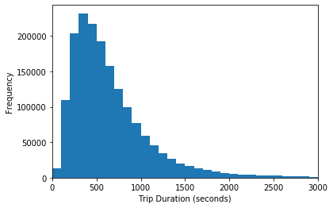

```python
bin_edges = np.arange (0, df_clean['duration_sec'].max()+100, 100)
plt.hist(data = df_clean, x = 'duration_sec', bins = bin_edges)
plt.xlim(0, 3000)
plt.xlabel('Trip Duration (seconds)')
plt.ylabel('Frequency');
```

```python
# gauging bin limits are appropriate for the plot
df_clean['duration_sec'].describe()
```

```
count    1.725138e+06
mean     7.731038e+02
std      1.945196e+03
min      6.100000e+01
25%      3.450000e+02
50%      5.430000e+02
75%      8.390000e+02
max      8.628100e+04
Name: duration_sec, dtype: float64
```

The data is a highly skewed long tailed distribution with the majority of trip durations being under 1000 seconds therefore it is appropriate to apply a logarithmic transformation to the data to gain a better understanding.

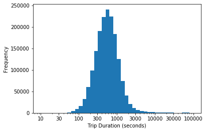

```python
bin_edges = 10 ** np.arange(1, 5 + 0.1, 0.1)
ticks = [10, 30, 100, 300, 1000, 3000, 10000, 30000, 100000]
plt.hist(data = df_clean, x = 'duration_sec', bins=bin_edges)
plt.xscale('log')
plt.xticks(ticks, ticks)
plt.xlabel('Trip Duration (seconds)')
plt.ylabel('Frequency');
```

```python
# for bin widths
np.log10(df_clean['duration_sec'].describe())
```

```
count    6.236824
mean     2.888238
std      3.288963
min      1.785330
25%      2.537819
50%      2.734800
75%      2.923762
max      4.935915
Name: duration_sec, dtype: float64
```

When plotted on a log scale, the bike trip duration looks normal, with a peak around 650 seconds. It will be useful for communication of findings to add a column which considers bike trip duration in minutes as opposed to seconds which is harder to comprehend.

```python
# creating a duration column in minutes
df_clean['duration_min'] = df_clean['duration_sec'] / 60
```

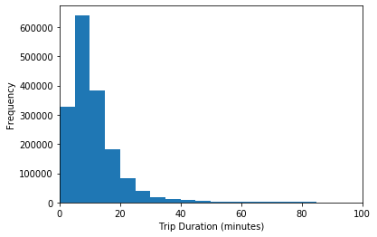

```python
bin_edges = np.arange (0, df_clean['duration_min'].max()+5, 5)
plt.hist(data = df_clean, x = 'duration_min', bins = bin_edges)
plt.xlim(0, 100)
plt.xlabel('Trip Duration (minutes)')
plt.ylabel('Frequency');
```

The data is highly skewed as when the units were in seconds therefore a log scale is again appropriate.

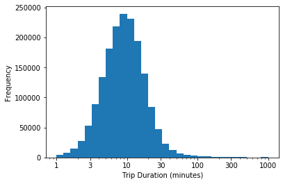

```python
bin_edges = 10 ** np.arange(0, 3 + 0.1, 0.1)
ticks = [1, 3, 10, 30, 100, 300, 1000]
plt.hist(data = df_clean, x = 'duration_min', bins=bin_edges)
plt.xscale('log')
plt.xticks(ticks, ticks)
plt.xlabel('Trip Duration (minutes)')
plt.ylabel('Frequency');
```

```python
# for bin edges
np.log10(df_clean['duration_min'].describe())
```

```
count    6.236824
mean     1.110087
std      1.510812
min      0.007179
25%      0.759668
50%      0.956649
75%      1.145611
max      3.157764
Name: duration_min, dtype: float64
```

```python
# finding the duration for different percentiles
df_clean['duration_min'].describe(percentiles = [0.25,0.5,0.75,0.9,0.95,0.99])
```

```
count    1.725138e+06
mean     1.288506e+01
std      3.241993e+01
min      1.016667e+00
25%      5.750000e+00
50%      9.050000e+00
75%      1.398333e+01
90%      2.085000e+01
95%      2.741667e+01
99%      6.438333e+01
max      1.438017e+03
Name: duration_min, dtype: float64
```

When plotted on a log scale with the trip duration in minutes it is highlighted that there is a peak around the 9-10 minute range. Additionally, it is evident from the above that 95% of bike trips are under half an hour.

Next the time of day was extracted and investigated as a predictor variable of interest.

```python
# extract the start hour of the trip from the start time variable
df_clean['start_hour'] = df_clean['start_time'].dt.strftime('%H')
```

```python
# check this worked
df_clean
```

|  | duration_sec | start_time | end_time | start_station_id | start_station_name | start_station_latitude | start_station_longitude | end_station_id | end_station_name | end_station_latitude | end_station_longitude | bike_id | user_type | member_birth_year | member_gender | bike_share_for_all_trip | duration_min | start_hour |
| --- | --- | --- | --- | --- | --- | --- | --- | --- | --- | --- | --- | --- | --- | --- | --- | --- | --- | --- |
| 0 | 75284 | 2018-01-31 22:52:35.239 | 2018-02-01 19:47:19.824 | 120 | Mission Dolores Park | 37.761420 | -122.426435 | 285 | Webster St at O'Farrell St | 37.783521 | -122.431158 | 2765 | Subscriber | 1986 | Male | No | 1254.733333 | 22 |
| 1 | 71576 | 2018-01-31 14:23:55.889 | 2018-02-01 10:16:52.116 | 304 | Jackson St at 5th St | 37.348759 | -121.894798 | 296 | 5th St at Virginia St | 37.325998 | -121.877120 | 3039 | Customer | 1996 | Male | No | 1192.933333 | 14 |
| 2 | 39966 | 2018-01-31 19:52:24.667 | 2018-02-01 06:58:31.053 | 74 | Laguna St at Hayes St | 37.776435 | -122.426244 | 19 | Post St at Kearny St | 37.788975 | -122.403452 | 617 | Subscriber | 1991 | Male | No | 666.100000 | 19 |
| 3 | 453 | 2018-01-31 23:53:53.632 | 2018-02-01 00:01:26.805 | 110 | 17th & Folsom Street Park (17th St at Folsom St) | 37.763708 | -122.415204 | 134 | Valencia St at 24th St | 37.752428 | -122.420628 | 3571 | Subscriber | 1988 | Male | No | 7.550000 | 23 |
| 4 | 180 | 2018-01-31 23:52:09.903 | 2018-01-31 23:55:10.807 | 81 | Berry St at 4th St | 37.775880 | -122.393170 | 93 | 4th St at Mission Bay Blvd S | 37.770407 | -122.391198 | 1403 | Subscriber | 1980 | Male | No | 3.000000 | 23 |
| ... | ... | ... | ... | ... | ... | ... | ... | ... | ... | ... | ... | ... | ... | ... | ... | ... | ... | ... |
| 1725133 | 1137 | 2018-12-01 00:01:49.693 | 2018-12-01 00:20:47.519 | 73 | Pierce St at Haight St | 37.771793 | -122.433708 | 50 | 2nd St at Townsend St | 37.780526 | -122.390288 | 273 | Subscriber | 1990 | Male | No | 18.950000 | 00 |
| 1725134 | 473 | 2018-12-01 00:11:54.811 | 2018-12-01 00:19:48.547 | 345 | Hubbell St at 16th St | 37.766474 | -122.398295 | 81 | Berry St at 4th St | 37.775880 | -122.393170 | 3035 | Subscriber | 1982 | Female | No | 7.883333 | 00 |
| 1725135 | 841 | 2018-12-01 00:02:48.726 | 2018-12-01 00:16:49.766 | 10 | Washington St at Kearny St | 37.795393 | -122.404770 | 58 | Market St at 10th St | 37.776619 | -122.417385 | 2034 | Subscriber | 1999 | Female | No | 14.016667 | 00 |
| 1725136 | 260 | 2018-12-01 00:05:27.615 | 2018-12-01 00:09:47.956 | 245 | Downtown Berkeley BART | 37.870139 | -122.268422 | 255 | Virginia St at Shattuck Ave | 37.876573 | -122.269528 | 2243 | Subscriber | 1991 | Male | No | 4.333333 | 00 |
| 1725137 | 292 | 2018-12-01 00:03:06.549 | 2018-12-01 00:07:59.080 | 93 | 4th St at Mission Bay Blvd S | 37.770407 | -122.391198 | 126 | Esprit Park | 37.761634 | -122.390648 | 545 | Subscriber | 1963 | Male | No | 4.866667 | 00 |

1725138 rows × 18 columns

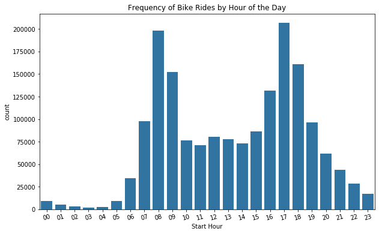

```python
# plot the frequency of bike rides by hour of the day
plt.figure(figsize=[10,6])
base_color = sb.color_palette()[0]
sb.countplot(data = df_clean, x = 'start_hour', color = base_color)
plt.xlabel('Start Hour')
plt.title('Frequency of Bike Rides by Hour of the Day')
plt.xticks(rotation=15);
```

It is clear from the plot above that more bike trips are taken during commuting hours of 7am - 9am and then 4pm-7pm. Next it will be interesting to extract the day to tell if this is happening on weekdays when people will use the bikes to travel to work.

```python
# extracting the day of the week from 'start_time'
df_clean['day'] = df_clean['start_time'].dt.strftime('%A')
```

```python
df_clean
```

|  | duration_sec | start_time | end_time | start_station_id | start_station_name | start_station_latitude | start_station_longitude | end_station_id | end_station_name | end_station_latitude | end_station_longitude | bike_id | user_type | member_birth_year | member_gender | bike_share_for_all_trip | duration_min | start_hour | day |
| --- | --- | --- | --- | --- | --- | --- | --- | --- | --- | --- | --- | --- | --- | --- | --- | --- | --- | --- | --- |
| 0 | 75284 | 2018-01-31 22:52:35.239 | 2018-02-01 19:47:19.824 | 120 | Mission Dolores Park | 37.761420 | -122.426435 | 285 | Webster St at O'Farrell St | 37.783521 | -122.431158 | 2765 | Subscriber | 1986 | Male | No | 1254.733333 | 22 | Wednesday |
| 1 | 71576 | 2018-01-31 14:23:55.889 | 2018-02-01 10:16:52.116 | 304 | Jackson St at 5th St | 37.348759 | -121.894798 | 296 | 5th St at Virginia St | 37.325998 | -121.877120 | 3039 | Customer | 1996 | Male | No | 1192.933333 | 14 | Wednesday |
| 2 | 39966 | 2018-01-31 19:52:24.667 | 2018-02-01 06:58:31.053 | 74 | Laguna St at Hayes St | 37.776435 | -122.426244 | 19 | Post St at Kearny St | 37.788975 | -122.403452 | 617 | Subscriber | 1991 | Male | No | 666.100000 | 19 | Wednesday |
| 3 | 453 | 2018-01-31 23:53:53.632 | 2018-02-01 00:01:26.805 | 110 | 17th & Folsom Street Park (17th St at Folsom St) | 37.763708 | -122.415204 | 134 | Valencia St at 24th St | 37.752428 | -122.420628 | 3571 | Subscriber | 1988 | Male | No | 7.550000 | 23 | Wednesday |
| 4 | 180 | 2018-01-31 23:52:09.903 | 2018-01-31 23:55:10.807 | 81 | Berry St at 4th St | 37.775880 | -122.393170 | 93 | 4th St at Mission Bay Blvd S | 37.770407 | -122.391198 | 1403 | Subscriber | 1980 | Male | No | 3.000000 | 23 | Wednesday |
| ... | ... | ... | ... | ... | ... | ... | ... | ... | ... | ... | ... | ... | ... | ... | ... | ... | ... | ... | ... |
| 1725133 | 1137 | 2018-12-01 00:01:49.693 | 2018-12-01 00:20:47.519 | 73 | Pierce St at Haight St | 37.771793 | -122.433708 | 50 | 2nd St at Townsend St | 37.780526 | -122.390288 | 273 | Subscriber | 1990 | Male | No | 18.950000 | 00 | Saturday |
| 1725134 | 473 | 2018-12-01 00:11:54.811 | 2018-12-01 00:19:48.547 | 345 | Hubbell St at 16th St | 37.766474 | -122.398295 | 81 | Berry St at 4th St | 37.775880 | -122.393170 | 3035 | Subscriber | 1982 | Female | No | 7.883333 | 00 | Saturday |
| 1725135 | 841 | 2018-12-01 00:02:48.726 | 2018-12-01 00:16:49.766 | 10 | Washington St at Kearny St | 37.795393 | -122.404770 | 58 | Market St at 10th St | 37.776619 | -122.417385 | 2034 | Subscriber | 1999 | Female | No | 14.016667 | 00 | Saturday |
| 1725136 | 260 | 2018-12-01 00:05:27.615 | 2018-12-01 00:09:47.956 | 245 | Downtown Berkeley BART | 37.870139 | -122.268422 | 255 | Virginia St at Shattuck Ave | 37.876573 | -122.269528 | 2243 | Subscriber | 1991 | Male | No | 4.333333 | 00 | Saturday |
| 1725137 | 292 | 2018-12-01 00:03:06.549 | 2018-12-01 00:07:59.080 | 93 | 4th St at Mission Bay Blvd S | 37.770407 | -122.391198 | 126 | Esprit Park | 37.761634 | -122.390648 | 545 | Subscriber | 1963 | Male | No | 4.866667 | 00 | Saturday |

1725138 rows × 19 columns

```python
# ordering the days of the week
df_clean['day'] = pd.Categorical(df_clean['day'], categories= ['Monday','Tuesday','Wednesday','Thursday','Friday','Saturday', 'Sunday'],ordered=True)
```

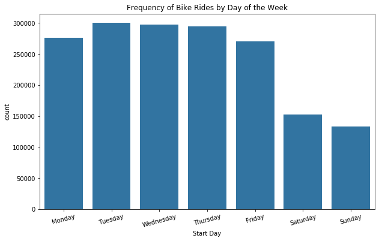

```python
# plotting the frequency of bike rides by the day of the week
plt.figure(figsize=[10,6])
base_color = sb.color_palette()[0]
sb.countplot(data = df_clean, x = 'day', color = base_color)
plt.xlabel('Start Day')
plt.title('Frequency of Bike Rides by Day of the Week')
plt.xticks(rotation=15);
```

From the above graph it is evident that the most popular days for taking bike trips is during weekdays which suggests that the bikes are being used for commuting to work as suspected.

Next, the time of year was investigated to understand if fewer people ride bikes during the colder winter months. Therefore, the months were extracted from the 'start_time' column as a string.

```python
# Extract month from the 'start_time' variable
df_clean['month'] = df_clean['start_time'].dt.strftime('%B')
```

```python
# check it worked
df_clean
```

|  | duration_sec | start_time | end_time | start_station_id | start_station_name | start_station_latitude | start_station_longitude | end_station_id | end_station_name | end_station_latitude | end_station_longitude | bike_id | user_type | member_birth_year | member_gender | bike_share_for_all_trip | duration_min | start_hour | day | month |
| --- | --- | --- | --- | --- | --- | --- | --- | --- | --- | --- | --- | --- | --- | --- | --- | --- | --- | --- | --- | --- |
| 0 | 75284 | 2018-01-31 22:52:35.239 | 2018-02-01 19:47:19.824 | 120 | Mission Dolores Park | 37.761420 | -122.426435 | 285 | Webster St at O'Farrell St | 37.783521 | -122.431158 | 2765 | Subscriber | 1986 | Male | No | 1254.733333 | 22 | Wednesday | January |
| 1 | 71576 | 2018-01-31 14:23:55.889 | 2018-02-01 10:16:52.116 | 304 | Jackson St at 5th St | 37.348759 | -121.894798 | 296 | 5th St at Virginia St | 37.325998 | -121.877120 | 3039 | Customer | 1996 | Male | No | 1192.933333 | 14 | Wednesday | January |
| 2 | 39966 | 2018-01-31 19:52:24.667 | 2018-02-01 06:58:31.053 | 74 | Laguna St at Hayes St | 37.776435 | -122.426244 | 19 | Post St at Kearny St | 37.788975 | -122.403452 | 617 | Subscriber | 1991 | Male | No | 666.100000 | 19 | Wednesday | January |
| 3 | 453 | 2018-01-31 23:53:53.632 | 2018-02-01 00:01:26.805 | 110 | 17th & Folsom Street Park (17th St at Folsom St) | 37.763708 | -122.415204 | 134 | Valencia St at 24th St | 37.752428 | -122.420628 | 3571 | Subscriber | 1988 | Male | No | 7.550000 | 23 | Wednesday | January |
| 4 | 180 | 2018-01-31 23:52:09.903 | 2018-01-31 23:55:10.807 | 81 | Berry St at 4th St | 37.775880 | -122.393170 | 93 | 4th St at Mission Bay Blvd S | 37.770407 | -122.391198 | 1403 | Subscriber | 1980 | Male | No | 3.000000 | 23 | Wednesday | January |
| ... | ... | ... | ... | ... | ... | ... | ... | ... | ... | ... | ... | ... | ... | ... | ... | ... | ... | ... | ... | ... |
| 1725133 | 1137 | 2018-12-01 00:01:49.693 | 2018-12-01 00:20:47.519 | 73 | Pierce St at Haight St | 37.771793 | -122.433708 | 50 | 2nd St at Townsend St | 37.780526 | -122.390288 | 273 | Subscriber | 1990 | Male | No | 18.950000 | 00 | Saturday | December |
| 1725134 | 473 | 2018-12-01 00:11:54.811 | 2018-12-01 00:19:48.547 | 345 | Hubbell St at 16th St | 37.766474 | -122.398295 | 81 | Berry St at 4th St | 37.775880 | -122.393170 | 3035 | Subscriber | 1982 | Female | No | 7.883333 | 00 | Saturday | December |
| 1725135 | 841 | 2018-12-01 00:02:48.726 | 2018-12-01 00:16:49.766 | 10 | Washington St at Kearny St | 37.795393 | -122.404770 | 58 | Market St at 10th St | 37.776619 | -122.417385 | 2034 | Subscriber | 1999 | Female | No | 14.016667 | 00 | Saturday | December |
| 1725136 | 260 | 2018-12-01 00:05:27.615 | 2018-12-01 00:09:47.956 | 245 | Downtown Berkeley BART | 37.870139 | -122.268422 | 255 | Virginia St at Shattuck Ave | 37.876573 | -122.269528 | 2243 | Subscriber | 1991 | Male | No | 4.333333 | 00 | Saturday | December |
| 1725137 | 292 | 2018-12-01 00:03:06.549 | 2018-12-01 00:07:59.080 | 93 | 4th St at Mission Bay Blvd S | 37.770407 | -122.391198 | 126 | Esprit Park | 37.761634 | -122.390648 | 545 | Subscriber | 1963 | Male | No | 4.866667 | 00 | Saturday | December |

1725138 rows × 20 columns

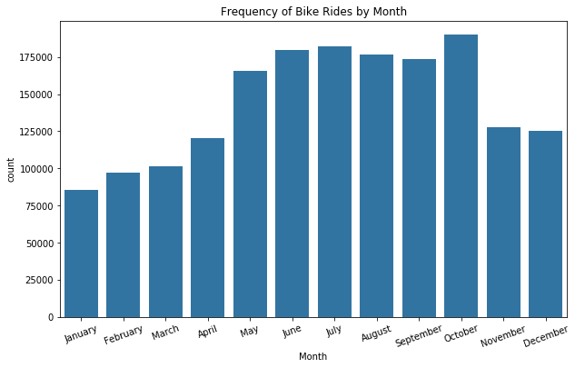

```python
#plot the frequency of bike rides by month
plt.figure(figsize=[10,6])
base_color = sb.color_palette()[0]
sb.countplot(data = df_clean, x = 'month', color = base_color)
plt.xlabel('Month')
plt.title('Frequency of Bike Rides by Month')
plt.xticks(rotation=20);
```

It is evident from the graph above that more bike trips were taking in the months from May - October. This is over the end of Spring - Autumn seasons. Evidently fewer people commuted during the Winter months.

Now that the time of day, day of the week, and month has been investigated next will be the user type to understand if more trips are taken by subscribers compared to customers.

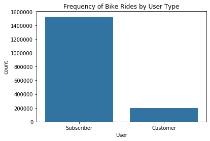

```python
# plot the frequency of bike rides by user type
base_color = sb.color_palette()[0]
user_order = df_clean['user_type'].value_counts().index
sb.countplot(data = df_clean, x = 'user_type', color = base_color, order = user_order)
plt.xlabel('User')
plt.title('Frequency of Bike Rides by User Type');
```

Subscribers to the program indeed take more bike trips than customers who are taking a one-off trip. It will be interesting to investigate if customers taking a one-off trip take longer bike trips than subscribers, this will be investigated in the next section where a bivariate exploration will be conducted.

For now, the age of the members taking bike rides will be investigated. An age column will be created from 'member_birth_year' which will help communicate findings in a clear way.

```python
#creating age column from member birth year (2018 - member birth year since this data is from 2018)
df_clean['age'] = (2018 - df_clean['member_birth_year'])
```

```python
# checking this worked
df_clean
```

|  | duration_sec | start_time | end_time | start_station_id | start_station_name | start_station_latitude | start_station_longitude | end_station_id | end_station_name | end_station_latitude | ... | bike_id | user_type | member_birth_year | member_gender | bike_share_for_all_trip | duration_min | start_hour | day | month | age |
| --- | --- | --- | --- | --- | --- | --- | --- | --- | --- | --- | --- | --- | --- | --- | --- | --- | --- | --- | --- | --- | --- |
| 0 | 75284 | 2018-01-31 22:52:35.239 | 2018-02-01 19:47:19.824 | 120 | Mission Dolores Park | 37.761420 | -122.426435 | 285 | Webster St at O'Farrell St | 37.783521 | ... | 2765 | Subscriber | 1986 | Male | No | 1254.733333 | 22 | Wednesday | January | 32 |
| 1 | 71576 | 2018-01-31 14:23:55.889 | 2018-02-01 10:16:52.116 | 304 | Jackson St at 5th St | 37.348759 | -121.894798 | 296 | 5th St at Virginia St | 37.325998 | ... | 3039 | Customer | 1996 | Male | No | 1192.933333 | 14 | Wednesday | January | 22 |
| 2 | 39966 | 2018-01-31 19:52:24.667 | 2018-02-01 06:58:31.053 | 74 | Laguna St at Hayes St | 37.776435 | -122.426244 | 19 | Post St at Kearny St | 37.788975 | ... | 617 | Subscriber | 1991 | Male | No | 666.100000 | 19 | Wednesday | January | 27 |
| 3 | 453 | 2018-01-31 23:53:53.632 | 2018-02-01 00:01:26.805 | 110 | 17th & Folsom Street Park (17th St at Folsom St) | 37.763708 | -122.415204 | 134 | Valencia St at 24th St | 37.752428 | ... | 3571 | Subscriber | 1988 | Male | No | 7.550000 | 23 | Wednesday | January | 30 |
| 4 | 180 | 2018-01-31 23:52:09.903 | 2018-01-31 23:55:10.807 | 81 | Berry St at 4th St | 37.775880 | -122.393170 | 93 | 4th St at Mission Bay Blvd S | 37.770407 | ... | 1403 | Subscriber | 1980 | Male | No | 3.000000 | 23 | Wednesday | January | 38 |
| ... | ... | ... | ... | ... | ... | ... | ... | ... | ... | ... | ... | ... | ... | ... | ... | ... | ... | ... | ... | ... | ... |
| 1725133 | 1137 | 2018-12-01 00:01:49.693 | 2018-12-01 00:20:47.519 | 73 | Pierce St at Haight St | 37.771793 | -122.433708 | 50 | 2nd St at Townsend St | 37.780526 | ... | 273 | Subscriber | 1990 | Male | No | 18.950000 | 00 | Saturday | December | 28 |
| 1725134 | 473 | 2018-12-01 00:11:54.811 | 2018-12-01 00:19:48.547 | 345 | Hubbell St at 16th St | 37.766474 | -122.398295 | 81 | Berry St at 4th St | 37.775880 | ... | 3035 | Subscriber | 1982 | Female | No | 7.883333 | 00 | Saturday | December | 36 |
| 1725135 | 841 | 2018-12-01 00:02:48.726 | 2018-12-01 00:16:49.766 | 10 | Washington St at Kearny St | 37.795393 | -122.404770 | 58 | Market St at 10th St | 37.776619 | ... | 2034 | Subscriber | 1999 | Female | No | 14.016667 | 00 | Saturday | December | 19 |
| 1725136 | 260 | 2018-12-01 00:05:27.615 | 2018-12-01 00:09:47.956 | 245 | Downtown Berkeley BART | 37.870139 | -122.268422 | 255 | Virginia St at Shattuck Ave | 37.876573 | ... | 2243 | Subscriber | 1991 | Male | No | 4.333333 | 00 | Saturday | December | 27 |
| 1725137 | 292 | 2018-12-01 00:03:06.549 | 2018-12-01 00:07:59.080 | 93 | 4th St at Mission Bay Blvd S | 37.770407 | -122.391198 | 126 | Esprit Park | 37.761634 | ... | 545 | Subscriber | 1963 | Male | No | 4.866667 | 00 | Saturday | December | 55 |

1725138 rows × 21 columns

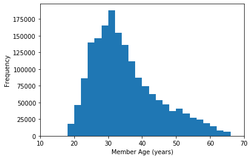

```python
# plotting age distribution
bin_edges = np.arange (10, df_clean['age'].max()+2, 2)
plt.hist(data = df_clean, x = 'age', bins = bin_edges)
plt.xlim(10, 70)
plt.xlabel('Member Age (years)')
plt.ylabel('Frequency');
```

From the graph above it is evident that there is a peak around 30 years. Next gender will be considered to understand if one gender uses FordGo Bikes more than others.

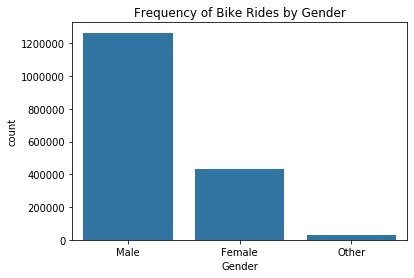

```python
# plotting gender
base_color = sb.color_palette()[0]
gender_order = df_clean['member_gender'].value_counts().index
sb.countplot(data = df_clean, x = 'member_gender', color = base_color, order = gender_order)
plt.xlabel('Gender')
plt.title('Frequency of Bike Rides by Gender');
```

It is evident that the majority of bike riders were male. Later in the investigation, the effect of gender on duration of bike trip will be examined.

It is now of interest to investigate the number of bike trips which were in the Bike Share for All scheme.

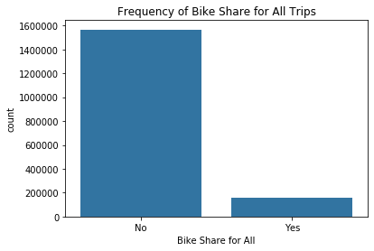

```python
base_color = sb.color_palette()[0]
share_order = df_clean['bike_share_for_all_trip'].value_counts().index
sb.countplot(data = df_clean, x = 'bike_share_for_all_trip', color = base_color, order = share_order)
plt.xlabel('Bike Share for All')
plt.title('Frequency of Bike Share for All Trips');
```

From the above we can see that the majority of trips taken were not involved in the Bike Share for All scheme.

Finally, distance will be calculated from the start and end longitude and latitude coordinates provided as the last section of the univariate exploration.

```python
# calculating the distance travelled during the bike trip
import numpy as np
def haversine_np(start_station_longitude, start_station_latitude, end_station_longitude, end_station_latitude):
    """
    Calculate the great circle distance between two points
    on the earth (specified in decimal degrees)
    All args must be of equal length.
    """
    start_station_longitude, start_station_latitude, end_station_longitude, end_station_latitude = map(np.radians, [start_station_longitude, start_station_latitude, end_station_longitude, end_station_latitude])
    dlon = end_station_longitude - start_station_longitude
    dlat = end_station_latitude - start_station_latitude
    a = np.sin(dlat/2.0)**2 + np.cos(start_station_latitude) * np.cos(end_station_latitude) * np.sin(dlon/2.0)**2
    c = 2 * np.arcsin(np.sqrt(a))
    km = 6367 * c
    return km
```

```python
# creating a distance column
df_clean['distance'] = haversine_np(df_clean['start_station_longitude'],df_clean['start_station_latitude'],df_clean['end_station_longitude'],df_clean['end_station_latitude'])
```

```python
# checking that this worked
df_clean
```

|  | duration_sec | start_time | end_time | start_station_id | start_station_name | start_station_latitude | start_station_longitude | end_station_id | end_station_name | end_station_latitude | ... | user_type | member_birth_year | member_gender | bike_share_for_all_trip | duration_min | start_hour | day | month | age | distance |
| --- | --- | --- | --- | --- | --- | --- | --- | --- | --- | --- | --- | --- | --- | --- | --- | --- | --- | --- | --- | --- | --- |
| 0 | 75284 | 2018-01-31 22:52:35.239 | 2018-02-01 19:47:19.824 | 120 | Mission Dolores Park | 37.761420 | -122.426435 | 285 | Webster St at O'Farrell St | 37.783521 | ... | Subscriber | 1986 | Male | No | 1254.733333 | 22 | Wednesday | January | 32 | 2.490689 |
| 1 | 71576 | 2018-01-31 14:23:55.889 | 2018-02-01 10:16:52.116 | 304 | Jackson St at 5th St | 37.348759 | -121.894798 | 296 | 5th St at Virginia St | 37.325998 | ... | Customer | 1996 | Male | No | 1192.933333 | 14 | Wednesday | January | 22 | 2.972635 |
| 2 | 39966 | 2018-01-31 19:52:24.667 | 2018-02-01 06:58:31.053 | 74 | Laguna St at Hayes St | 37.776435 | -122.426244 | 19 | Post St at Kearny St | 37.788975 | ... | Subscriber | 1991 | Male | No | 666.100000 | 19 | Wednesday | January | 27 | 2.439039 |
| 3 | 453 | 2018-01-31 23:53:53.632 | 2018-02-01 00:01:26.805 | 110 | 17th & Folsom Street Park (17th St at Folsom St) | 37.763708 | -122.415204 | 134 | Valencia St at 24th St | 37.752428 | ... | Subscriber | 1988 | Male | No | 7.550000 | 23 | Wednesday | January | 30 | 1.341075 |
| 4 | 180 | 2018-01-31 23:52:09.903 | 2018-01-31 23:55:10.807 | 81 | Berry St at 4th St | 37.775880 | -122.393170 | 93 | 4th St at Mission Bay Blvd S | 37.770407 | ... | Subscriber | 1980 | Male | No | 3.000000 | 23 | Wednesday | January | 38 | 0.632321 |
| ... | ... | ... | ... | ... | ... | ... | ... | ... | ... | ... | ... | ... | ... | ... | ... | ... | ... | ... | ... | ... | ... |
| 1725133 | 1137 | 2018-12-01 00:01:49.693 | 2018-12-01 00:20:47.519 | 73 | Pierce St at Haight St | 37.771793 | -122.433708 | 50 | 2nd St at Townsend St | 37.780526 | ... | Subscriber | 1990 | Male | No | 18.950000 | 00 | Saturday | December | 28 | 3.935288 |
| 1725134 | 473 | 2018-12-01 00:11:54.811 | 2018-12-01 00:19:48.547 | 345 | Hubbell St at 16th St | 37.766474 | -122.398295 | 81 | Berry St at 4th St | 37.775880 | ... | Subscriber | 1982 | Female | No | 7.883333 | 00 | Saturday | December | 36 | 1.138059 |
| 1725135 | 841 | 2018-12-01 00:02:48.726 | 2018-12-01 00:16:49.766 | 10 | Washington St at Kearny St | 37.795393 | -122.404770 | 58 | Market St at 10th St | 37.776619 | ... | Subscriber | 1999 | Female | No | 14.016667 | 00 | Saturday | December | 19 | 2.362164 |
| 1725136 | 260 | 2018-12-01 00:05:27.615 | 2018-12-01 00:09:47.956 | 245 | Downtown Berkeley BART | 37.870139 | -122.268422 | 255 | Virginia St at Shattuck Ave | 37.876573 | ... | Subscriber | 1991 | Male | No | 4.333333 | 00 | Saturday | December | 27 | 0.721480 |
| 1725137 | 292 | 2018-12-01 00:03:06.549 | 2018-12-01 00:07:59.080 | 93 | 4th St at Mission Bay Blvd S | 37.770407 | -122.391198 | 126 | Esprit Park | 37.761634 | ... | Subscriber | 1963 | Male | No | 4.866667 | 00 | Saturday | December | 55 | 0.976111 |

1725138 rows × 22 columns

Now that distance has been created, outliers will be identified and removed.

```python
df_clean.distance.describe()
```

```
count    1.725138e+06
mean     1.597989e+00
std      1.020239e+00
min      0.000000e+00
25%      8.771934e-01
50%      1.376481e+00
75%      2.087145e+00
max      6.526825e+01
Name: distance, dtype: float64
```

```python
df_clean.query("distance > 20")
```

|  | duration_sec | start_time | end_time | start_station_id | start_station_name | start_station_latitude | start_station_longitude | end_station_id | end_station_name | end_station_latitude | ... | user_type | member_birth_year | member_gender | bike_share_for_all_trip | duration_min | start_hour | day | month | age | distance |
| --- | --- | --- | --- | --- | --- | --- | --- | --- | --- | --- | --- | --- | --- | --- | --- | --- | --- | --- | --- | --- | --- |
| 189738 | 21836 | 2018-03-29 14:25:47.670 | 2018-03-29 20:29:44.284 | 16 | Steuart St at Market St | 37.79413 | -122.39443 | 303 | San Pedro St at Hedding St | 37.352601 | ... | Customer | 1974 | Female | No | 363.933333 | 14 | Thursday | March | 44 | 65.26825 |

1 rows × 22 columns

```python
df_clean = df_clean.drop(df_clean[df_clean.distance > 20].index)
```

```python
df_clean.distance.describe()
```

```
count    1.725137e+06
mean     1.597952e+00
std      1.019087e+00
min      0.000000e+00
25%      8.771934e-01
50%      1.376481e+00
75%      2.087145e+00
max      1.652760e+01
Name: distance, dtype: float64
```

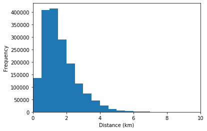

```python
# plotting distance distribution
bin_edges = np.arange (0, df_clean['distance'].max()+0.5, 0.5)
plt.hist(data = df_clean, x = 'distance', bins = bin_edges)
plt.xlabel('Distance (km)')
plt.xlim(0,10)
plt.ylabel('Frequency');
```

From the above it is evident that most trips were under 2km which agrees with the finding that most bike trips lasted around 10 minutes.

#### Univariate Exploration Conclusions

The duration of bike trips was highly skewed to the right therefore a log scale was used instead to give a log normal distribution. The duration of bike trips in minutes was added to the data so it was easier to comprehend. It is clear from the graph produced that the majority of bike rides are under 30 minutes with the average time being around the 9-10 minute mark.

Additionally, time of day and day of the week was investigated and suggested the bikes were being used for commuting to work since the most popular times were from 07:00-09:00 and 16:00-19:00 on weekdays. A month column was also added to give insight into the frequency of bike trips by each month of the year. It was evident that as expected there were more bike trips taken during the warmer months from May - October.

An age column was added to determine the age of the members in the year 2018 when this data was gathered. The graph illustrated a peak of riders around 30 years old. The data was cleaned to remove those over the age of 65 which was done by removing the top 1% of the dataset.

It was found there were more subscribers than customers taking bike trips. Furthermore, more males took bike trips compared to those registered as female or other. The majority of trips were not part of the bike share for all trip scheme.

Moreover, the longitude and latitude columns were used to create a distance column to indicate the distance travelled during the trip. The majority of bike trips were under 2km.

### Bivariate Exploration

Bivariate exploration will now be conducted to investigate if there are any correlations in the data.

```python
df_clean.info()
```

```
<class 'pandas.core.frame.DataFrame'>
Int64Index: 1725137 entries, 0 to 1725137
Data columns (total 22 columns):
 #   Column                   Dtype
---  ------                   -----
 0   duration_sec             int64
 1   start_time               datetime64[ns]
 2   end_time                 datetime64[ns]
 3   start_station_id         object
 4   start_station_name       object
 5   start_station_latitude   float64
 6   start_station_longitude  float64
 7   end_station_id           object
 8   end_station_name         object
 9   end_station_latitude     float64
 10  end_station_longitude    float64
 11  bike_id                  object
 12  user_type                category
 13  member_birth_year        int32
 14  member_gender            category
 15  bike_share_for_all_trip  category
 16  duration_min             float64
 17  start_hour               object
 18  day                      category
 19  month                    object
 20  age                      int32
 21  distance                 float64
dtypes: category(4), datetime64[ns](2), float64(6), int32(2), int64(1), object(7)
memory usage: 243.5+ MB
```

```python
# assigning numeric and categoric variables for easy plotting
numeric_vars = ['duration_min', 'age', 'distance']
categoric_vars = ['member_gender', 'user_type', 'bike_share_for_all_trip', 'month', 'day', 'start_hour']
```

First the relationship between the numeric variables will be examined to look for any possible correlations.

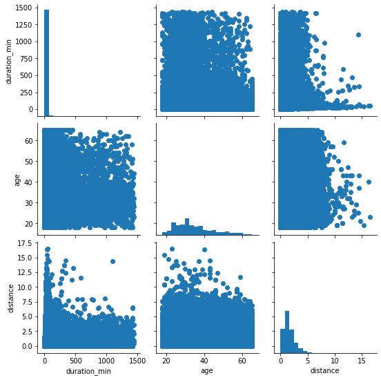

```python
g = sb.PairGrid(data = df_clean, vars = numeric_vars)
g = g.map_diag(plt.hist, bins = 20);
g.map_offdiag(plt.scatter)
```

From the above plots it is clear there aren't strong correlations between the numeric variables, therefore the relationships between our numeric and categoric variables and between different categoric variables will be explored.

Duration of bike trips in minutes and it's relation to other features is investigated below with the y axis cut to show trips between 0 and 50 minutes.

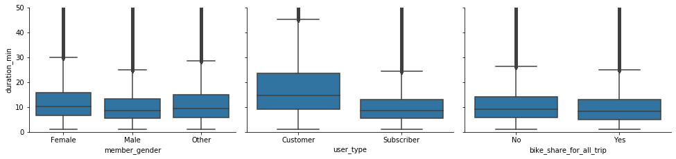

```python
def boxgrid(x, y, **kwargs):
    default_color = sb.color_palette()[0]
    sb.boxplot(x, y, color = default_color)

plt.figure(figsize = [16, 16])
g = sb.PairGrid(data = df_clean, y_vars = 'duration_min', x_vars = ['member_gender', 'user_type', 'bike_share_for_all_trip'],
                size = 3, aspect = 1.5)
plt.ylim (0, 50)
g.map(boxgrid)
plt.show();
```

From the above plot it is evident that females and those identifying as other actually take longer bike trips than males on average. Moreover, interestingly more customers take longer bike trips than subsribers suggesting that when customers do take a one-off trip they take longer trips. The bike share for all trip scheme doesn't significantly affect the bike trip duration therefore this will no longer be considered during the rest of the investigation.

Next the features relating to time of day, day of week and month of the year will be investigated.

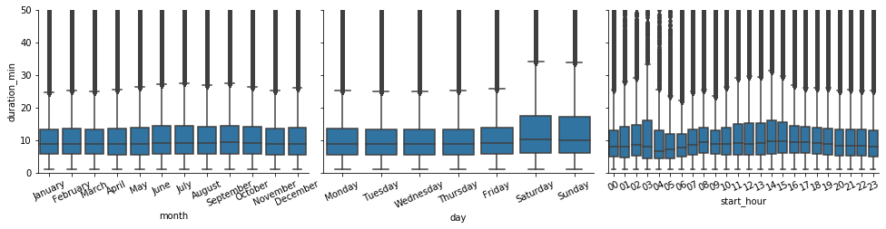

```python
def boxgrid(x, y, **kwargs):
    default_color = sb.color_palette()[0]
    sb.boxplot(x, y, color = default_color)

plt.figure(figsize = [16, 16])
g = sb.PairGrid(data = df_clean, y_vars = 'duration_min', x_vars = ['month', 'day', 'start_hour'],
                size = 3, aspect = 1.5)
plt.ylim (0, 50)
rotation = 25
for i, ax in enumerate(g.fig.axes):   ## getting all axes of the fig object
     ax.set_xticklabels(ax.get_xticklabels(), rotation = rotation)
g.fig.show()
g.map(boxgrid)
plt.show();
```

From the above boxplots it is clear that time of year didn't significantly affect duration of bike trip, however it did show a slight increase in the warmer summer months. The day of the week had an effect on trip duration with longer bike rides taking place at the weekend. In addition longer bike trips took place in the afternoon between 14:00 - 15:00.

Next the other features and their relationships will be briefly explored.

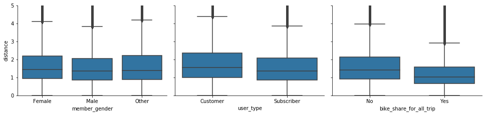

```python
# Looking at box plots to understand relationships between quantitative and qualitative variables
def boxgrid(x, y, **kwargs):
    default_color = sb.color_palette()[0]
    sb.boxplot(x, y, color = default_color)

plt.figure(figsize = [12, 12])

g = sb.PairGrid(data = df_clean, y_vars = ['distance'], x_vars = ['member_gender', 'user_type', 'bike_share_for_all_trip'],
                size = 3, aspect = 1.5)
g.map(boxgrid)
plt.ylim(0, 5)
plt.show();
```

From the above it is clear that some variables had a slight effect on the distance travelled with females and those who selected 'other' as their gender travelled a greater distance, as did customers as opposed to subscribers, and those not involved in the bike share for all also travelled a greater distance.

Next we will briefly look at distance and the remaining variables.

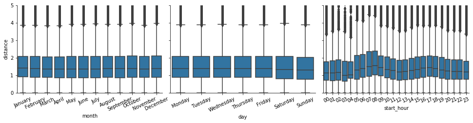

```python
# Looking at box plots to understand relationships between quantitative and qualitative variables
def boxgrid(x, y, **kwargs):
    default_color = sb.color_palette()[0]
    sb.boxplot(x, y, color = default_color)

plt.figure(figsize = [12, 12])
g = sb.PairGrid(data = df_clean, y_vars = ['distance'], x_vars = ['month', 'day', 'start_hour'],
                size = 3, aspect = 1.5)
rotation = 25
for i, ax in enumerate(g.fig.axes):   ## getting all axes of the fig object
     ax.set_xticklabels(ax.get_xticklabels(), rotation = rotation)
g.fig.show()
g.map(boxgrid)
plt.ylim(0, 5)
plt.show();
```

From the above it is clear that month or day of the week doesn't affect distance travelled however it is evident that a greater distance was travelled in the mornings, especially from 7am-8am. However, no further analysis will be performed with distance since there is not an interesting relationship which can be further explored. Next, age in relation to other variables will be explored.

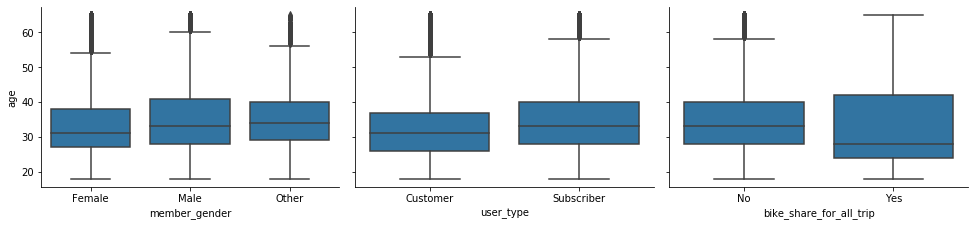

```python
# Looking at box plots to understand relationships between quantitative and qualitative variables
def boxgrid(x, y, **kwargs):
    default_color = sb.color_palette()[0]
    sb.boxplot(x, y, color = default_color)

plt.figure(figsize = [12, 12])
g = sb.PairGrid(data = df_clean, y_vars = ['age'], x_vars = ['member_gender', 'user_type', 'bike_share_for_all_trip'],
                size = 3, aspect = 1.5)
g.map(boxgrid)
plt.show();
```

From the boxplot above, it is clear that most members are in their early 30s regardless of gender or user type. Interestingly, those involved in the bike share for all scheme are on average younger than those who aren't involved which is possibly as it is for low income members and it's possible these are younger on average.

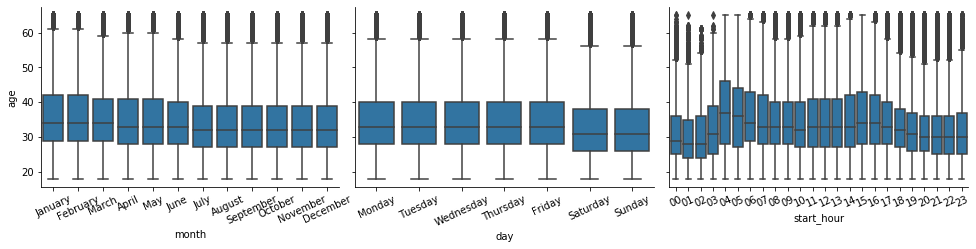

```python
# Looking at box plots to understand relationships between quantitative and qualitative variables
def boxgrid(x, y, **kwargs):
    default_color = sb.color_palette()[0]
    sb.boxplot(x, y, color = default_color)

plt.figure(figsize = [12, 12])
g = sb.PairGrid(data = df_clean, y_vars = ['age'], x_vars = ['month', 'day', 'start_hour'],
                size = 3, aspect = 1.5)
rotation = 25
for i, ax in enumerate(g.fig.axes):   ## getting all axes of the fig object
     ax.set_xticklabels(ax.get_xticklabels(), rotation = rotation)
g.fig.show()
g.map(boxgrid)
plt.show();
```

From the above plot it is highlighted that younger people took bike trips at the weekend. Trips taken during very late at night and into the hours of the very early morning were taken by younger people on average. Moving forward, 'age', 'distance' and 'bike share for all' won't be used in any further analysis since there were no more interesting relationships found with these variables.

Next the relationship between user type and gender is investigated.

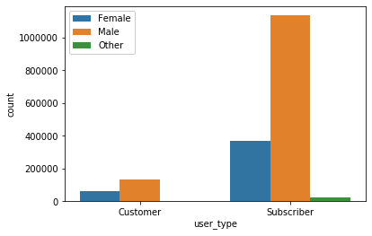

```python
#clustered bar chart
ax = sb.countplot(data = df_clean, x = 'user_type', hue = 'member_gender')
ax.legend(loc = 2, framealpha = 1)
```

From this clustered bar chart it is evident that subscribers took more bike rides than customers as previously established and the majority of both subscribers and customers were male.

#### Bivariate Exploration Conclusions

##### Features of Interest

During this part of the investigation it was found that on average those who identified as female or other as their gender took longer bike rides than males. Additionally, customers took longer bike rides than those who were members. Those not involved in the bike share for all scheme took longer bike trips. Time of year didn't significantly affect duration of bike trip, however it did show a slight increase in the warmer summer months. The day of the week had an effect on trip duration with longer bike rides taking place at the weekend. In addition longer bike trips took place between the hours of 2-3pm.

Interestingly more trips are taken at the beginning of the year by members who are slightly older. With regards to day of the week, more younger people took bike trips at the weekend. Trips taken during very late at night and into the hours of the very early morning were taken by younger people.

When considering demographics from this clustered bar chart it is evident that subscribers took more bike rides than customers and the majority of both subscribers and customers were male.

##### Other Features

When considering other features in the dataset, from the above exploration it is evident that those who identified as female or other travelled a slightly greater distance than males and customers travelled further than subscribers on average, however this was very slight. Those who were not in the bike share for all scheme also travelled a slightly longer distance than those who were involved in the scheme. When considering the demographics of the members it is clear that most members are in their early 30s. Moreover, those involved in the bike share for all scheme are on average younger than those who aren't involved.

Moving forward, 'age', 'distance' and 'bike share for all' won't be used in any further analysis as these are not related to the features of interest and don't show strong relationships with other features in the dataset.

### Multivariate Exploration

Next, multivariate plots will be used to understand the relationship between the features of interest which are duration and frequency of bike trips with other categorical variables including gender, user type, and time of day and day of the week.

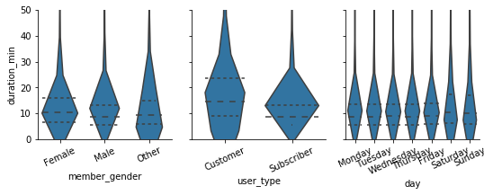

```python
# PairGrid to look at relationship between numeric and categorical variables
g = sb.PairGrid(data = df_clean, y_vars = 'duration_min',
                x_vars = ['member_gender', 'user_type', 'day'])
plt.ylim(0, 50)
rotation = 25
for i, ax in enumerate(g.fig.axes):   ## getting all axes of the fig object
     ax.set_xticklabels(ax.get_xticklabels(), rotation = rotation)
g.map(sb.violinplot, inner = 'quartile')
g.fig.show()
```

A clustered bar chart highlighting the relationship between duration, user type and gender will now be plotted.

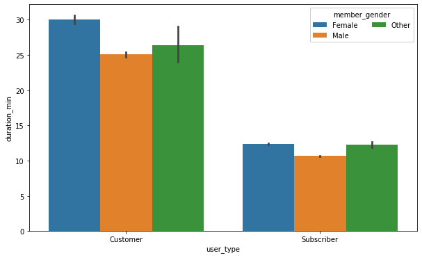

```python
# clustered bar chart
plt.figure(figsize = [10, 6])
ax = sb.barplot(data = df_clean, x = 'user_type', y = 'duration_min', hue = 'member_gender')
ax.legend(loc = 1, ncol = 2, framealpha = 1, title = 'member_gender')
```

From the above it is shown that females and others took longer bike trips than males regardless of whether they were customers or subscribers.

A clustered bar chart will be plotted next to understand the relationship between duration, day of week and gender.

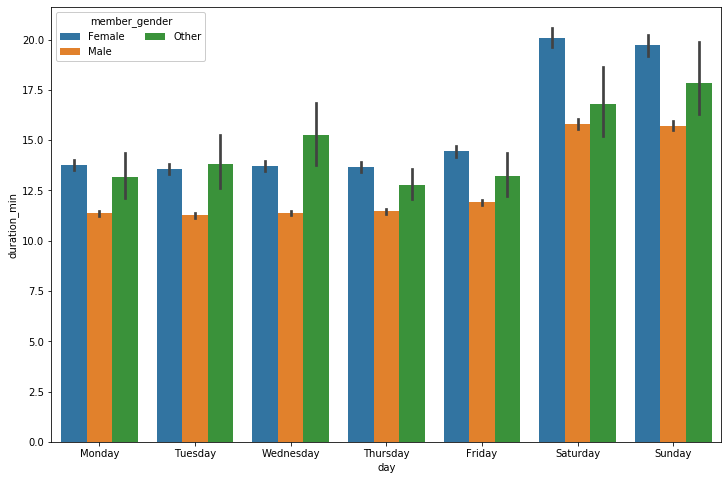

```python
# clustered bar chart
plt.figure(figsize = [12, 8])
ax = sb.barplot(data = df_clean, x = 'day', y = 'duration_min', hue = 'member_gender')
ax.legend(loc = 2, ncol = 2, framealpha = 1, title = 'member_gender')
```

As illustrated above, genders which were female and other took longer bike rides than males everyday of the week and all genders took longer bike trips on weekends. Now the relationship between duration,user type and day of the week will be examined.

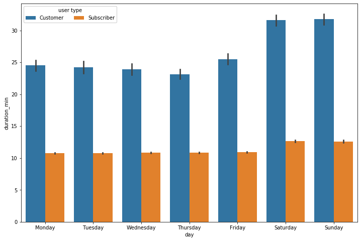

```python
# clustered bar chart
plt.figure(figsize = [12, 8])
ax = sb.barplot(data = df_clean, x = 'day', y = 'duration_min', hue = 'user_type')
ax.legend(loc = 2, ncol = 2, framealpha = 1, title = 'user type')
```

From above it is clear that customers took longer bike rides than subscribers every day of the week and both customers and subscribers took longer trips at the weekends.

Next a heatmap to visualise frequency of bike trips, day of the week and time of day will be plotted.

Please note that a data visualisations article linked in the References and here: [https://dfrieds.com/data-visualizations/when-use-heatmaps.html] was used to create the following heatmap of frequency of bike rides.

```python
# creating DataFrame 2 for the visulation. Source: https://dfrieds.com/data-visualizations/when-use-heatmaps.html
df_clean2 = pd.pivot_table(df_clean[['day', 'start_hour', 'duration_min']], index=['day', 'start_hour'], aggfunc='count')
```

```python
# put days on x axis and hour of day on y axis. Source: https://dfrieds.com/data-visualizations/when-use-heatmaps.html
df_clean3 = df_clean2.unstack(level=0)
```

```python
# check to see if it worked
df_clean3
```

| day start_hour | duration_min Monday | duration_min Tuesday | duration_min Wednesday | duration_min Thursday | duration_min Friday | duration_min Saturday | duration_min Sunday |
| --- | --- | --- | --- | --- | --- | --- | --- |
| 00 | 895 | 883 | 1018 | 1126 | 1372 | 2107 | 1934 |
| 01 | 455 | 487 | 533 | 502 | 714 | 1333 | 1248 |
| 02 | 360 | 292 | 336 | 372 | 360 | 754 | 799 |
| 03 | 228 | 235 | 201 | 263 | 259 | 347 | 364 |
| 04 | 376 | 377 | 372 | 355 | 349 | 246 | 243 |
| 05 | 1504 | 1922 | 1780 | 1630 | 1473 | 460 | 341 |
| 06 | 6133 | 7354 | 6845 | 6767 | 5475 | 1010 | 646 |
| 07 | 17509 | 20907 | 19942 | 19229 | 16260 | 2213 | 1596 |
| 08 | 35971 | 40801 | 40066 | 38924 | 33706 | 4982 | 3455 |
| 09 | 26900 | 28740 | 28561 | 28617 | 26081 | 7401 | 5955 |
| 10 | 10800 | 11634 | 11988 | 11893 | 11994 | 9613 | 8612 |
| 11 | 8918 | 9653 | 9868 | 10062 | 10402 | 11598 | 10310 |
| 12 | 10349 | 10923 | 11394 | 11696 | 11685 | 12958 | 11473 |
| 13 | 9855 | 10025 | 10739 | 10317 | 11406 | 13322 | 11857 |
| 14 | 9137 | 9115 | 9536 | 9597 | 11007 | 13028 | 11797 |
| 15 | 11127 | 11947 | 12290 | 12357 | 14069 | 12777 | 11749 |
| 16 | 20597 | 21679 | 21779 | 21543 | 22350 | 12223 | 11478 |
| 17 | 37167 | 39224 | 38071 | 37649 | 32832 | 11327 | 10451 |
| 18 | 28819 | 30918 | 29562 | 28837 | 23204 | 10226 | 9138 |
| 19 | 16732 | 17637 | 17362 | 17008 | 13135 | 7676 | 6944 |
| 20 | 10290 | 11088 | 10981 | 10971 | 7910 | 5715 | 4997 |
| 21 | 6558 | 7401 | 7491 | 7520 | 6093 | 4690 | 3887 |
| 22 | 3740 | 4514 | 4588 | 4886 | 4800 | 3609 | 2464 |
| 23 | 1851 | 2333 | 2419 | 2719 | 3475 | 2835 | 1616 |

```python
# create new labels. Source: https://dfrieds.com/data-visualizations/when-use-heatmaps.html
am_hrs = []
for hr in range(1, 12):
    complete_hr = str(hr) + "am"
    am_hrs.append(complete_hr)
```

```python
# create new labels. Source: https://dfrieds.com/data-visualizations/when-use-heatmaps.html
pm_hrs = []
for hr in range(1, 12):
    complete_hr = str(hr) + "pm"
    pm_hrs.append(complete_hr)
```

```python
# create new labels. Source: https://dfrieds.com/data-visualizations/when-use-heatmaps.html
complete_hrs = ["12am"] + am_hrs + ["12pm"] + pm_hrs
day_abbr = ['Mon', 'Tues', 'Wed', 'Thurs', 'Fri', 'Sat', 'Sun']
```

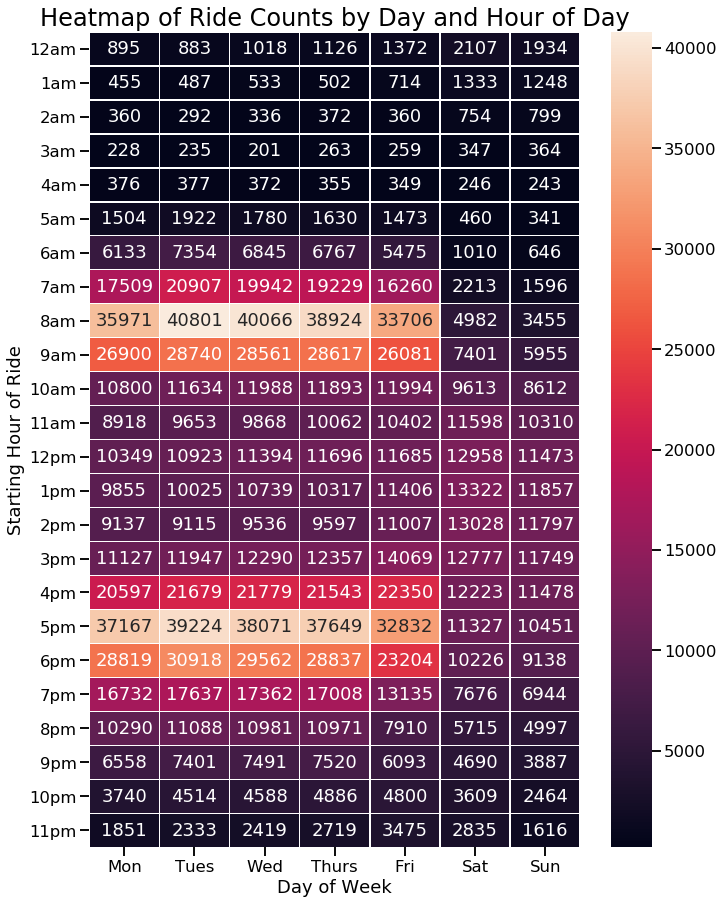

```python
# heatmap of bike trip frequency. Source: https://dfrieds.com/data-visualizations/when-use-heatmaps.html
sb.set_context("talk")
f, ax = plt.subplots(figsize=(11, 15))
ax = sb.heatmap(df_clean3, annot=True, fmt="d", linewidths=.5, ax=ax, xticklabels=day_abbr, yticklabels=complete_hrs)
ax.axes.set_title("Heatmap of Ride Counts by Day and Hour of Day", fontsize=24, y=1.01)
ax.set(xlabel='Day of Week', ylabel='Starting Hour of Ride');
```

The heatmap above indicates that on Weekdays most bike trips occur between 7am-9am and 4pm - 7pm which are typically times when people commute to work. The same technique was then used to visualise this relationship between time of day, and day of week with duration of bike ride.

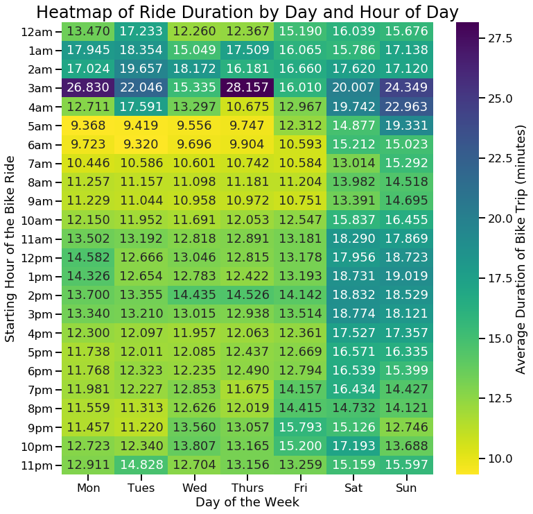

```python
# heatmap for bike trip duration
plt.figure(figsize = [12, 12])
cat_means = df_clean.groupby(['day', 'start_hour']).mean()['duration_min']
cat_means = cat_means.reset_index(name = 'duration_min_avg')
cat_means = cat_means.pivot(index = 'start_hour', columns = 'day',
                            values = 'duration_min_avg')
sb.heatmap(cat_means, annot = True, fmt = '.3f',
           cbar_kws = {'label' : 'Average Duration of Bike Trip (minutes)'}, xticklabels=day_abbr, yticklabels=complete_hrs,
          cmap="viridis_r")
plt.xlabel("Day of the Week")
plt.ylabel("Starting Hour of the Bike Ride")
plt.title("Heatmap of Ride Duration by Day and Hour of Day",  fontsize=24, y=1.01);
```

The above heatmap indicates that the average duration of bike rides is longer during the weekends than weekdays. It is also shown that the longest bike trips on average take place during the early hours of the morning.

#### Multivariate Exploration Conclusions

The investigation of bike trip length and frequency was extended by looking at the impact of day of week and time of day. The multivariate exploration highlighted that time of day and day of the week had an effect on the frequency of bike trips taken with most taken during weekdays and commuting hours as people were using the bike to travel to work.

As expected more bike trips indeed occurred during commuting hours however, and that longer bike trips on average occurred during the weekends compared to the weekdays. However, it was surprising that during weekdays some of the longest duration of bike trips took place between 1am-3am.

It was found that all genders took longer bike rides at the weekends and those identifying as 'female' or 'other' took longer bike trips on all days. Moreover, customers took longer trips than subscribers on all days of the week.

### Storing Data

```python
# save cleaned df_clean as a csv
df_clean.to_csv('2018-fordgobike-data-clean.csv', index = False)
```

## Conclusions

In the exploration, I found that most bike trips lasted under 30 minutes with the average lasting around approximately 9 minutes. It was also found that most trips were under 2km. I found that most users of Ford GoBikes used the bikes between typical commuting hours and on weekdays suggesting that a number of cyclists were using the bikes to travel to work. Additionally, it was found that frequency would increase during the warmer months of the year and would be less during the colder winter months.

It was found that most users of the service are subscribers compared to a rather small proportion who were customers, although it was interesting to find that when customers do use the bikes then they take longer bike trips than subscribers do on average.

When considering how demographics affects bike trip frequency and duration it was found that the service was most popular with those in their mid twenties to mid thirties and number of users decreased after the age of thirty for every increase in year of age. Additionally it was found that males were more likely to use the service however it was interesting that when females or those who selected 'other' as their gender took bike trips then these lasted longer than those taken by males. In addition it was found that the majority of bike trips were not part of the Bike Share for All Scheme.

When conducting a bivariate exploration of the data, it was clear there were not strong correlations between the numeric variables in the dataset i.e age, duration, distance. However, several insights into the relationships with categorical variables were found. As aforementioned, females and those identified as 'other' took longer bike trips than males and customers took longer trips than subscribers. There was no strong relationship found between duration of trip and if a participant was involved in the bike share for all scheme. It was found that the month of the year didn't have a strong effect on the duration of the bike trip, however the day of the week was related with longer trips happening during the weekends. Time of day also affected the length of the trip with longer trips during the afternoon.

Outside of the main variables of interest it was found that females and those who selected 'other' as their gender travelled a greater distance, as did customers as opposed to subscribers, and those not involved in the bike share for all also travelled a greater distance. From the above it is clear that month or day of the week doesn't affect distance travelled however it is evident that a greater distance was travelled in the mornings, especially from 7am-8am. When investigating age most members were in their early 30s regardless of gender or user type. Interestingly, those involved in the bike share for all scheme are on average younger than those who aren't involved which is possibly as it is for low income members and it's possible these are younger on average. Younger people took bike trips at the weekend. Trips taken during very late at night and into the hours of the very early morning were taken by younger people on average.

## References

https://knowledge.udacity.com/questions/205686  
https://stackoverflow.com/questions/20490274/how-to-reset-index-in-a-pandas-dataframe  
https://towardsdatascience.com/ways-to-detect-and-remove-the-outliers-404d16608dba  
https://medium.com/analytics-vidhya/outlier-treatment-9bbe87384d02  
https://stackoverflow.com/questions/26105804/extract-month-from-date-in-python/26105855  
https://stackoverflow.com/questions/51102615/get-month-from-date-column  
https://stackoverflow.com/questions/25754405/how-to-extract-hours-and-minutes-from-a-datetime-datetime-object https://stackoverflow.com/questions/29545704/fast-haversine-approximation-python-pandas  
https://stackoverflow.com/questions/26540035/rotate-label-text-in-seaborn-factorplot  
https://dfrieds.com/data-visualizations/when-use-heatmaps.html  
https://matplotlib.org/3.3.1/tutorials/colors/colormaps.html